# AI_CA5_P2_810197682

```python
from google.colab import drive
drive.mount('/content/drive')
```

```python
!cp "/content/drive/MyDrive/UTKFace.tar.gz" .
```

```python
!tar xvzf UTKFace.tar.gz
```

```python
import os
import math
import glob
import tensorboard
import numpy as np
import pandas as pd
import tensorflow as tf
import matplotlib.pyplot as plt

from tensorflow.keras import *
from tensorflow.keras.utils import *
from keras.preprocessing.image import image
from sklearn.metrics import classification_report

%matplotlib inline
```

# **Phase#1 - Preprocess**

```python
def find_label(image_addr):
  splited_addr = image_addr.split('_')
  if len(splited_addr) != 4: return -1
  race = splited_addr[2]
  return race

images = glob.glob("/content/UTKFace" + "/*.jpg")
races, dump_images = [], []

for img in images:
  z = find_label(img)
  if z == -1:
    dump_images.append(img)
  else:
    races.append(z)

for img in dump_images:
  images.remove(img)
```

```python
oneHot_races = []
for race in races:
  temp = ['0'] * 5
  temp[int(race)] = '1'
  oneHot_races.append("".join(temp))

train_df = pd.DataFrame(list(zip(images, races)), columns = ['Image','Race'])
train_df
```

### ● علت استفاده از وان-هات انکودینگ

برای استفاده از داده‌های کتگوریکال، باید آن‌ها را به داده‌های عددی تبدیل کنیم؛ برای این منظور، دو روش وجود دارد که یک کانت-وکتوریزیشن و دگیری وان-هات-انکودینگ است. در روش اول، به هر لیبل یک عدد اختصاص داده می شود که استفاده از این روش توصیه نمی شود زیرا ممکن است میان لیبل ها رابطه معنایی ایجاد کند که خوب نیست. بنابراین، ما از روش دوم استفاده می‌نماییم.

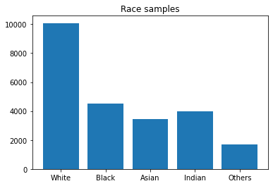

```python
race_types = [0] * 5
titels = ["White", "Black", "Asian", "Indian", "Others"]

for i in races:
  race_types[int(i)] += 1

plt.bar(titels, race_types)
plt.title('Race samples')
plt.show()
```

```
race  Black :
```

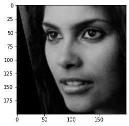

```
race  Indian :
```

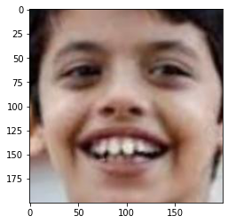

```
race  White :
```

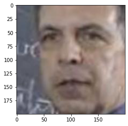

```
race  Asian :
```

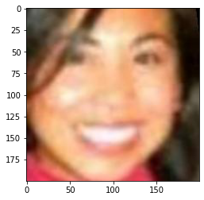

```
race  Others :
```

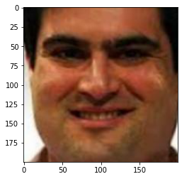

```python
j = 0
seen = []

for i in range(len(images)):
  if j == 5:
    break
  if races[i] not in seen:
    seen.append(races[i])
    j += 1
    print("Race ", titels[int(races[i])],':')
    img = image.load_img(images[i])
    img = image.img_to_array(img)
    plt.imshow(img/255)
    plt.show()
```

# **Phase#2 - Design Neural Network**

```python
def generate_train_test():
  dataGenerator = preprocessing.image.ImageDataGenerator(rescale = 1./255, validation_split = 0.3)

  train = dataGenerator.flow_from_dataframe(
  dataframe = train_df,
  x_col = "Image",
  y_col = "Race",
  subset = "training",
  color_mode = "grayscale",
  batch_size = 32,
  shuffle = False,
  class_mode = "categorical",
  target_size = (100,100))

  test = dataGenerator.flow_from_dataframe(
  dataframe=train_df,
  x_col = "Image",
  y_col = "Race",
  subset = "validation",
  color_mode = "grayscale",
  batch_size = 32,
  shuffle = False,
  class_mode = "categorical",
  target_size = (100,100))

  return train, test

train_data, test_data = generate_train_test()
```

```
Found 16594 validated image filenames belonging to 5 classes.
Found 7111 validated image filenames belonging to 5 classes.
```

```python
def get_model_info(model, result):
  plt.figure()
  plt.ylabel("loss")
  plt.xlabel("epoch")
  plt.plot(result.epoch, result.history["val_loss"], label = "val", color = "red")
  plt.plot(result.epoch, result.history["loss"], label = "train", color = "blue")
  plt.legend()
  plt.show()

  plt.figure()
  plt.ylabel("accuracy")
  plt.xlabel("epoch")
  plt.plot(result.epoch, result.history["val_accuracy"], label = 'val', color = "red")
  plt.plot(result.epoch, result.history["accuracy"], label = 'train', color = "blue")
  plt.legend()
  plt.show()

  predict = model.predict(test_data)
  predict = backend.argmax(predict).numpy()
  target_names = ["White", "Black", "Asian", "Indian", "Others"]
  print(classification_report(test_data.labels, predict, target_names = target_names))
  print(model.summary())
```

```python
input = layers.Input(shape = (100, 100, 1))

flattenLayer = layers.Flatten()(input)
hiddenLayer1 = layers.Dense(1024, activation="relu")(flattenLayer)
hiddenLayer2 = layers.Dense(1024, activation="relu")(hiddenLayer1)
hiddenLayer3 = layers.Dense(1024, activation="relu")(hiddenLayer2)
output = layers.Dense(5, activation = "softmax")(hiddenLayer3)
```

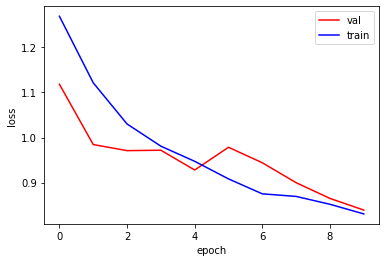

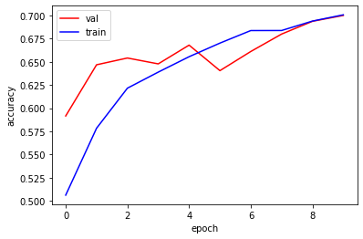

```
              precision    recall  f1-score   support

       White       0.66      0.91      0.77      2984
       Black       0.81      0.73      0.77      1370
       Asian       0.80      0.56      0.66      1023
      Indian       0.65      0.57      0.61      1209
      Others       0.33      0.01      0.02       525

    accuracy                           0.70      7111
   macro avg       0.65      0.56      0.56      7111
weighted avg       0.68      0.70      0.67      7111

Model: "model_3"
_________________________________________________________________
Layer (type)                 Output Shape              Param #
=================================================================
input_4 (InputLayer)         [(None, 100, 100, 1)]     0
_________________________________________________________________
flatten_3 (Flatten)          (None, 10000)             0
_________________________________________________________________
dense_11 (Dense)             (None, 1024)              10241024
_________________________________________________________________
dense_12 (Dense)             (None, 1024)              1049600
_________________________________________________________________
dense_13 (Dense)             (None, 1024)              1049600
_________________________________________________________________
dense_14 (Dense)             (None, 5)                 5125
=================================================================
Total params: 12,345,349
Trainable params: 12,345,349
Non-trainable params: 0
_________________________________________________________________
None
```

```python
model = models.Model(inputs = input, outputs = output)
model.compile(optimizer = optimizers.SGD(learning_rate = 0.01), loss = "categorical_crossentropy", metrics = ["accuracy"])
result = model.fit(train_data, validation_data = test_data, epochs = 10)
get_model_info(model, result)
```

# **Phase#3 - Optimizer**

**Optimizer-Momentum 0.5**

```python
input = layers.Input(shape = (100, 100, 1))

flattenLayer = layers.Flatten()(input)
hiddenLayer1 = layers.Dense(1024, activation = "relu")(flattenLayer)
hiddenLayer2 = layers.Dense(1024, activation = "relu")(hiddenLayer1)
hiddenLayer3 = layers.Dense(1024, activation = "relu")(hiddenLayer2)
output = layers.Dense(5, activation = "softmax")(hiddenLayer3)
```

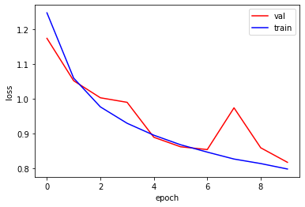

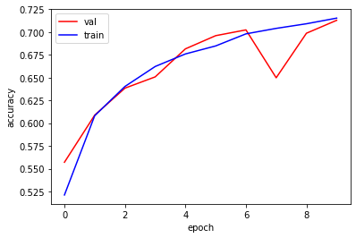

```
              precision    recall  f1-score   support

       White       0.73      0.83      0.78      2984
       Black       0.77      0.80      0.78      1370
       Asian       0.71      0.68      0.69      1023
      Indian       0.61      0.68      0.64      1209
      Others       0.00      0.00      0.00       525

    accuracy                           0.71      7111
   macro avg       0.56      0.60      0.58      7111
weighted avg       0.66      0.71      0.69      7111

Model: "model_4"
_________________________________________________________________
Layer (type)                 Output Shape              Param #
=================================================================
input_6 (InputLayer)         [(None, 100, 100, 1)]     0
_________________________________________________________________
flatten_5 (Flatten)          (None, 10000)             0
_________________________________________________________________
dense_19 (Dense)             (None, 1024)              10241024
_________________________________________________________________
dense_20 (Dense)             (None, 1024)              1049600
_________________________________________________________________
dense_21 (Dense)             (None, 1024)              1049600
_________________________________________________________________
dense_22 (Dense)             (None, 5)                 5125
=================================================================
Total params: 12,345,349
Trainable params: 12,345,349
Non-trainable params: 0
_________________________________________________________________
None
```

```python
model = models.Model(inputs = input, outputs = output)
model.compile(optimizer = optimizers.SGD(learning_rate = 0.01, momentum = 0.5), loss = "categorical_crossentropy", metrics = ["accuracy"])
result = model.fit(train_data, validation_data = test_data, epochs = 10)
get_model_info(model, result)
```

**Optimizer-Momentum 0.9**

```python
input = layers.Input(shape = (100, 100, 1))

flattenLayer = layers.Flatten()(input)
hiddenLayer1 = layers.Dense(1024, activation = "relu")(flattenLayer)
hiddenLayer2 = layers.Dense(1024, activation = "relu")(hiddenLayer1)
hiddenLayer3 = layers.Dense(1024, activation = "relu")(hiddenLayer2)
output = layers.Dense(5, activation = "softmax")(hiddenLayer3)
```

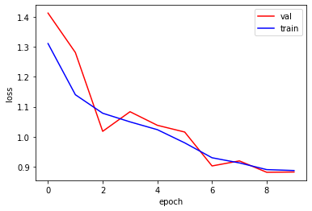

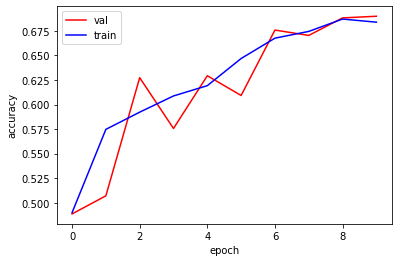

```
              precision    recall  f1-score   support

       White       0.67      0.87      0.76      2984
       Black       0.74      0.77      0.75      1370
       Asian       0.83      0.53      0.65      1023
      Indian       0.61      0.59      0.60      1209
      Others       0.00      0.00      0.00       525

    accuracy                           0.69      7111
   macro avg       0.57      0.55      0.55      7111
weighted avg       0.65      0.69      0.66      7111

Model: "model_5"
_________________________________________________________________
Layer (type)                 Output Shape              Param #
=================================================================
input_7 (InputLayer)         [(None, 100, 100, 1)]     0
_________________________________________________________________
flatten_6 (Flatten)          (None, 10000)             0
_________________________________________________________________
dense_23 (Dense)             (None, 1024)              10241024
_________________________________________________________________
dense_24 (Dense)             (None, 1024)              1049600
_________________________________________________________________
dense_25 (Dense)             (None, 1024)              1049600
_________________________________________________________________
dense_26 (Dense)             (None, 5)                 5125
=================================================================
Total params: 12,345,349
Trainable params: 12,345,349
Non-trainable params: 0
_________________________________________________________________
None
```

```python
model = models.Model(inputs = input, outputs = output)
model.compile(optimizer = optimizers.SGD(learning_rate = 0.01, momentum = 0.9), loss = "categorical_crossentropy", metrics = ["accuracy"])
result = model.fit(train_data, validation_data = test_data, epochs = 10)
get_model_info(model, result)
```

**Optimizer-Adam**

```python
input = layers.Input(shape = (100, 100, 1))

flattenLayer = layers.Flatten()(input)
hiddenLayer1 = layers.Dense(1024, activation = "relu")(flattenLayer)
hiddenLayer2 = layers.Dense(1024, activation = "relu")(hiddenLayer1)
hiddenLayer3 = layers.Dense(1024, activation = "relu")(hiddenLayer2)
output = layers.Dense(5, activation = "softmax")(hiddenLayer3)
```

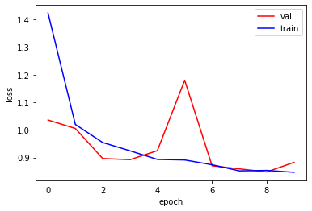

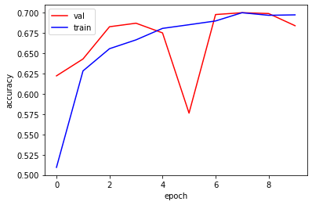

```
              precision    recall  f1-score   support

       White       0.69      0.85      0.76      2984
       Black       0.84      0.68      0.75      1370
       Asian       0.83      0.49      0.62      1023
      Indian       0.53      0.74      0.62      1209
      Others       0.00      0.00      0.00       525

    accuracy                           0.68      7111
   macro avg       0.58      0.55      0.55      7111
weighted avg       0.66      0.68      0.66      7111

Model: "model_6"
_________________________________________________________________
Layer (type)                 Output Shape              Param #
=================================================================
input_8 (InputLayer)         [(None, 100, 100, 1)]     0
_________________________________________________________________
flatten_7 (Flatten)          (None, 10000)             0
_________________________________________________________________
dense_27 (Dense)             (None, 1024)              10241024
_________________________________________________________________
dense_28 (Dense)             (None, 1024)              1049600
_________________________________________________________________
dense_29 (Dense)             (None, 1024)              1049600
_________________________________________________________________
dense_30 (Dense)             (None, 5)                 5125
=================================================================
Total params: 12,345,349
Trainable params: 12,345,349
Non-trainable params: 0
_________________________________________________________________
None
```

```python
model = models.Model(inputs = input, outputs = output)
model.compile(optimizer = optimizers.Adam(), loss = "categorical_crossentropy", metrics = ["accuracy"])
result = model.fit(train_data, validation_data = test_data, epochs = 10)
get_model_info(model, result)
```

### ● مومنتوم چیست و چرا از آن استفاده می‌کنیم؟

Momentum in neural networks is a variant of the stochastic gradient descent. It replaces the gradient with a momentum.

The momentum factor is a coefficient that is applied to an extra term in the weight update.

$$ \Delta W_{i,j} = LearningRate \times \frac{\partial E}{\partial W_{i,j}} $$

changes to:

$$ \Delta W_{i,j} = LearningRate \times \frac{\partial E}{\partial W_{i,j}} + \lambda \times \Delta W_{i,j}^{t - 1} $$

where $\lambda$ is momentum factor.

It helps to speed up learning and help not getting stuck in local minima.

[Reference](https://datascience.stackexchange.com/questions/84167/what-is-momentum-in-neural-network)

### ● تاثیر استفاده از مومنتوم

همان‌طور که در نمودارها قابل مشاهده است، ما زودتر به جواب بهینه رسیدیم (در ایپاک‌های اولیه) اما پراکندگی خطا واضح است. دلیل آن نیز استفاده از عبارت اضافه شده است که باعث سریع تر شدن اما مقدار خیلی کمی بدتر شدن می‌شود. لازم به ذکر است که در مقدار مومنتوم 0.9 به نسبت 0.5 هم سرعت کمتر شده و هم پراکندگی‌ها بیشتر می‌شود که این بعلت تکانه بیش از حد آن است.

### ● آیا همیشه استفاده از مومنتوم باعث بهبود نتیجه می‌شود؟

خیر زیرا اگر مومنتوم فکتور خیلی زیاد باشد، گرادیان نمی‌تواند به آن برسد و مسیر خودش را طی می‌کند. اصولا برای تابع اروری که خیلی بالا و پایین دارد، اگه از مومنتوم استفاده کنیم، احتمالا نتیجه‌ی خیلی خوبی نمی‌گیریم.

### ● تاثیر استفاده از بهینه‌ساز آدام

خصوصیت آدام نسبت به اس‌جی‌دی این است که به شدت سریع‌تر همگرا می‌شود و در اجرای ما این به طور مشخصی واضح است و البته باعث اورفیت شدن داده آموزش نیز می‌شود.

# **Phase#3 - Epochs**

```python
input = layers.Input(shape = (100, 100, 1))

flattenLayer = layers.Flatten()(input)
hiddenLayer1 = layers.Dense(1024, activation = "relu")(flattenLayer)
hiddenLayer2 = layers.Dense(1024, activation = "relu")(hiddenLayer1)
hiddenLayer3 = layers.Dense(1024, activation = "relu")(hiddenLayer2)
output = layers.Dense(5, activation = "softmax")(hiddenLayer3)
```

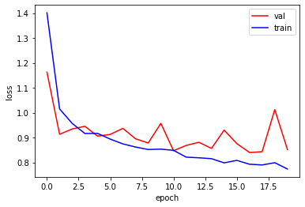

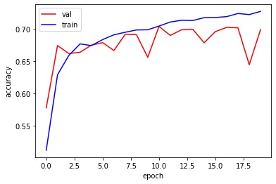

```
              precision    recall  f1-score   support

       White       0.70      0.85      0.77      2984
       Black       0.86      0.65      0.74      1370
       Asian       0.67      0.74      0.70      1023
      Indian       0.59      0.65      0.62      1209
      Others       0.25      0.00      0.00       525

    accuracy                           0.70      7111
   macro avg       0.61      0.58      0.57      7111
weighted avg       0.67      0.70      0.67      7111

Model: "model_7"
_________________________________________________________________
Layer (type)                 Output Shape              Param #
=================================================================
input_9 (InputLayer)         [(None, 100, 100, 1)]     0
_________________________________________________________________
flatten_8 (Flatten)          (None, 10000)             0
_________________________________________________________________
dense_31 (Dense)             (None, 1024)              10241024
_________________________________________________________________
dense_32 (Dense)             (None, 1024)              1049600
_________________________________________________________________
dense_33 (Dense)             (None, 1024)              1049600
_________________________________________________________________
dense_34 (Dense)             (None, 5)                 5125
=================================================================
Total params: 12,345,349
Trainable params: 12,345,349
Non-trainable params: 0
_________________________________________________________________
None
```

```python
model = models.Model(inputs = input, outputs = output)
model.compile(optimizer = optimizers.Adam(), loss = "categorical_crossentropy", metrics = ["accuracy"])
result = model.fit(train_data, validation_data = test_data, epochs = 20)
get_model_info(model, result)
```

### ● علت استفاده از چند ایپاچ

برای آن که داده‌های ما برای آموزش کامل شبکه کافی نیستند و ما مجبوریم برای این که شبکه به طور کامل آموزش داده شود، چندین بار از داده‌های آموزش استفاده کنیم. و اینکه در همه‌ی مسائل نیاز نیست از چند ایپاچ استفاده نماییم اما در بیش‌تر مسائل به دلیل پیچیده بودن شبکه‌ها، شبکه به مقدار اصلی‌اش همگرا نمی‌شود مگر این که داده‌هایمان خیلی خیلی زیاد باشد.

### ● تاثیر استفاده از ایپاچ‌های بیشتر

خیر مفید نیست. زیرا بعد از یک جایی شبکه داده‌ها را حفظ می‌کند و اورفیتینگ رخ می‌دهد. راه‌حل مقابله با این شرایط، این است که ایپاک‌ها را تا زمانی ادامه بدهیم که دقتمان در داده‌های تست خیلی زیاد کم نشود

# **Phase#3 - loss funcs**

```python
input = layers.Input(shape = (100, 100, 1))

flattenLayer = layers.Flatten()(input)
hiddenLayer1 = layers.Dense(1024, activation = "relu")(flattenLayer)
hiddenLayer2 = layers.Dense(1024, activation = "relu")(hiddenLayer1)
hiddenLayer3 = layers.Dense(1024, activation = "relu")(hiddenLayer2)
output = layers.Dense(5, activation = "softmax")(hiddenLayer3)
```

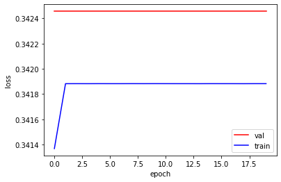

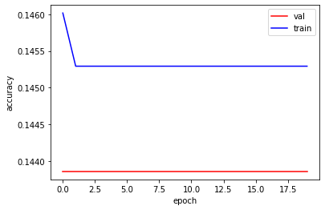

```
              precision    recall  f1-score   support

       White       0.00      0.00      0.00      2984
       Black       0.00      0.00      0.00      1370
       Asian       0.14      1.00      0.25      1023
      Indian       0.00      0.00      0.00      1209
      Others       0.00      0.00      0.00       525

    accuracy                           0.14      7111
   macro avg       0.03      0.20      0.05      7111
weighted avg       0.02      0.14      0.04      7111

Model: "model_8"
_________________________________________________________________
Layer (type)                 Output Shape              Param #
=================================================================
input_10 (InputLayer)        [(None, 100, 100, 1)]     0
_________________________________________________________________
flatten_9 (Flatten)          (None, 10000)             0
_________________________________________________________________
dense_35 (Dense)             (None, 1024)              10241024
_________________________________________________________________
dense_36 (Dense)             (None, 1024)              1049600
_________________________________________________________________
dense_37 (Dense)             (None, 1024)              1049600
_________________________________________________________________
dense_38 (Dense)             (None, 5)                 5125
=================================================================
Total params: 12,345,349
Trainable params: 12,345,349
Non-trainable params: 0
_________________________________________________________________
None
```

```python
model = models.Model(inputs = input, outputs = output)
model.compile(optimizer = optimizers.Adam(), loss = losses.MeanSquaredError(), metrics = ["accuracy"])
result = model.fit(train_data, validation_data = test_data, epochs = 20)
get_model_info(model, result)
```

### ● تاثیر استفاده از ام اس ای

استفاده از ام‌اس‌ای در صورتی مفید خواهد بود که فرض نرمال بودن خروجی برقرار در صورتی که این فرض برای مسائل دسته‌بندی برقرار نیست و اینکه تابع ام‌اس‌ای برای داده‌های دسته بندی، غیر خطی است پس تابع آن محدب نیست و در نتیجه بهترین نتیجه را لزوما نخواهد داد. [منبع](https://towardsdatascience.com/why-using-mean-squared-error-mse-cost-function-for-binary-classification-is-a-bad-idea-933089e90df7#:~:text=There%20are%20two%20reasons%20why,choice%20for%20binary%20classification%20problems%3A&text=If%20we%20use%20maximum%20likelihood,function%20for%20optimizing%20our%20model.)

# **Phase#3 - Regularization**

**Regularization-L2**

```python
input = layers.Input(shape = (100, 100, 1))

flattenLayer = layers.Flatten()(input)
hiddenLayer1 = layers.Dense(1024, activation = "relu", activity_regularizer = regularizers.l2(1e-4))(flattenLayer)
hiddenLayer2 = layers.Dense(1024, activation = "relu", activity_regularizer = regularizers.l2(1e-4))(hiddenLayer1)
hiddenLayer3 = layers.Dense(1024, activation = "relu", activity_regularizer = regularizers.l2(1e-4))(hiddenLayer2)
output = layers.Dense(5, activation = "softmax")(hiddenLayer3)
```

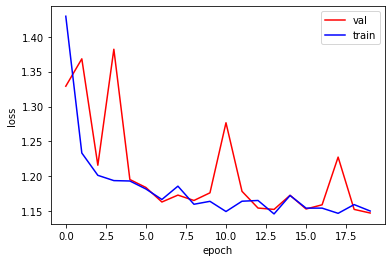

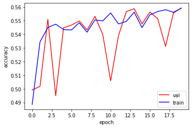

```
              precision    recall  f1-score   support

       White       0.54      0.91      0.68      2984
       Black       0.67      0.71      0.69      1370
       Asian       0.66      0.13      0.22      1023
      Indian       0.36      0.14      0.20      1209
      Others       0.00      0.00      0.00       525

    accuracy                           0.56      7111
   macro avg       0.45      0.38      0.36      7111
weighted avg       0.51      0.56      0.48      7111

Model: "model_9"
_________________________________________________________________
Layer (type)                 Output Shape              Param #
=================================================================
input_11 (InputLayer)        [(None, 100, 100, 1)]     0
_________________________________________________________________
flatten_10 (Flatten)         (None, 10000)             0
_________________________________________________________________
dense_39 (Dense)             (None, 1024)              10241024
_________________________________________________________________
dense_40 (Dense)             (None, 1024)              1049600
_________________________________________________________________
dense_41 (Dense)             (None, 1024)              1049600
_________________________________________________________________
dense_42 (Dense)             (None, 5)                 5125
=================================================================
Total params: 12,345,349
Trainable params: 12,345,349
Non-trainable params: 0
_________________________________________________________________
None
```

```python
model = models.Model(inputs = input, outputs = output)
model.compile(optimizer = optimizers.Adam(), loss = "categorical_crossentropy", metrics = ["accuracy"])
result = model.fit(train_data, validation_data = test_data, epochs = 20)
get_model_info(model, result)
```

**Regularization-Dropout**

```python
input = layers.Input(shape = (100, 100, 1))

flattenLayer = layers.Flatten()(input)
hiddenLayer1 = layers.Dense(1024, activation = "relu")(flattenLayer)
dropout1 = layers.Dropout(0.1)(hiddenLayer1)
hiddenLayer2 = layers.Dense(1024, activation = "relu")(dropout1)
dropout2 = layers.Dropout(0.1)(hiddenLayer2)
hiddenLayer3 = layers.Dense(1024, activation = "relu")(dropout2)
dropout3 = layers.Dropout(0.1)(hiddenLayer3)
output = layers.Dense(5, activation = "softmax")(dropout3)
```

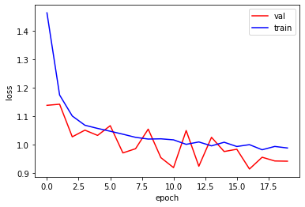

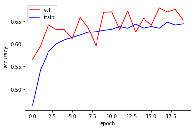

```
              precision    recall  f1-score   support

       White       0.59      0.93      0.73      2984
       Black       0.76      0.75      0.75      1370
       Asian       0.81      0.51      0.63      1023
      Indian       0.71      0.26      0.38      1209
      Others       0.00      0.00      0.00       525

    accuracy                           0.65      7111
   macro avg       0.57      0.49      0.50      7111
weighted avg       0.63      0.65      0.60      7111

Model: "model_10"
_________________________________________________________________
Layer (type)                 Output Shape              Param #
=================================================================
input_12 (InputLayer)        [(None, 100, 100, 1)]     0
_________________________________________________________________
flatten_11 (Flatten)         (None, 10000)             0
_________________________________________________________________
dense_43 (Dense)             (None, 1024)              10241024
_________________________________________________________________
dropout (Dropout)            (None, 1024)              0
_________________________________________________________________
dense_44 (Dense)             (None, 1024)              1049600
_________________________________________________________________
dropout_1 (Dropout)          (None, 1024)              0
_________________________________________________________________
dense_45 (Dense)             (None, 1024)              1049600
_________________________________________________________________
dropout_2 (Dropout)          (None, 1024)              0
_________________________________________________________________
dense_46 (Dense)             (None, 5)                 5125
=================================================================
Total params: 12,345,349
Trainable params: 12,345,349
Non-trainable params: 0
_________________________________________________________________
None
```

```python
model = models.Model(inputs = input, outputs = output)
model.compile(optimizer = optimizers.Adam(), loss = "categorical_crossentropy", metrics = ["accuracy"])
result = model.fit(train_data, validation_data = test_data, epochs = 20)
get_model_info(model, result)
```